# linearalgebra_practice107108109

```python
%%html
<style>
@import url('https://fonts.googleapis.com/css?family=Roboto&effect=3d|brick-sign|');
span {font-family:Roboto; color:black; text-shadow:4px 4px 4px #aaa;}
h1,h2 {font-family:Roboto; color:slategray; text-shadow:4px 4px 4px #aaa;}
div.output_subarea, div.output_area pre{font-family:Roboto; font_size:120%; color:darkblue;}
</style>
```

```python
import math, sympy, numpy
sympy.init_printing(use_unicode=True)
from sympy import *
from mpmath import *

import pylab as plt
%matplotlib inline
```

[Computer Algebra I: Mathematica, SymPy, Sage, Maxima](http://hyperpolyglot.org/computer-algebra2)

[SymPy. Numerical evaluation](https://docs.sympy.org/latest/modules/evalf.html)

LaTeX/Mathematics

[Wolfram Mathworld. Trigonometric Identities](http://mathworld.wolfram.com/topics/TrigonometricIdentities.html)

# Типовой расчет 7 / Standard Calculation 7

## Постановка задачи / Formulation of the problem:

Выполнить указанные действия с комплексными числами,

представив ответ в алгебраической форме:

$\large{Z_1 + Z_2, Z_2 - Z_3, Z_1 * Z_4, Z_2 / Z_5}$

$\large{Z_1 = 4 + 3 i; Z_2 = 1 + 2 i; Z_3 = 1 + 3 i; Z_4 = – 10 + i; Z_5 = – 7 + 6 i}$

```python
z1 = complex(4 + 3 * I)
z2 = complex(1 + 2 * I)
z3 = complex(1 + 3 * I)
z4 = complex(-10 + 1 * I)
z5 = complex(-7 + 6 * I)

z1, z2, z3, z4, z5
```

```
((4+3j), (1+2j), (1+3j), (-10+1j), (-7+6j))
```

## Решение / Decision

Сложение комплексных чисел.

$(a + bi) + (c + di) = (a + c) + (b + d)i$

$Z_1 + Z_2 = (4 + 3 i) + (1 + 2 i) = 5 + 5i$

Вычитание комплексных чисел.

$(a + bi) - (c + di) = (a - c) + (b - d)i$

$Z_2 - Z_3 = (1 + 2 i) - (1 + 3i)= - i$

Умножение комплексных чисел.

$(a + bi) * (c + di) = (ac - bd) + (ad + bc)i$

$Z_1 + Z_4 = (4 + 3 i) + (-10 + i) = (4 * (-10) - 3 * 1) + (4 * 1 + 3 * (-10))i = -43 -26i$

Деление комплексных чисел.

$\large{\frac{a + bi}{c + di} = \frac{(a + bi) * (c - di)}{(c + di) * (c - di)} = \frac{ac+ bd}{c^2 + d^2} + \frac{bc - ad}{c^2 + d^2}i}$

$\large{Z_2 / Z_5 = \frac{1 + 2i}{-7 + 6i} = \frac{1 * (-7) + 2 * 6}{(-7)^2 + 6^2} + \frac{2 * (-7) - 1 * 6}{(-7)^2 + 6^2}i} = \frac{1}{17} - \frac{4}{17}i$

```python
z1 + z2, z2 - z3, z1 * z4
```

```
((5+5j), -1j, (-43-26j))
```

```python
z2 / z5, (1/17, -4/17)
```

```
((0.0588235294117647-0.23529411764705885j),
 (0.058823529411764705, -0.23529411764705882))
```

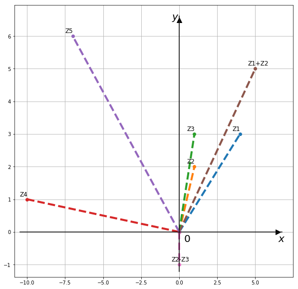

```python
C = numpy.array([4,1,1,-10,-7,5,0]) + 1j * numpy.array([3,2,3,1,6,5,-1])
x = [c.real for c in C]; y = [c.imag for c in C]; Z=['Z1','Z2','Z3','Z4','Z5','Z1+Z2','Z2-Z3']

fig, ax = plt.subplots(figsize=(10,10)); ax.grid(True)

for i in range(7):
    ax.plot([0,x[i]], [0,y[i]], '-o', lw=4, ls='--')
    ax.annotate(Z[i], (x[i]-0.5, y[i]+0.1), fontsize=12)

plt.text(6.5,-0.3,r'$x$', fontsize=20)
plt.text(-0.5,6.5,r'$y$', fontsize=20)
plt.text(0.3,-0.3,r'$0$', fontsize=20)

plt.scatter(0,6.5, marker='^', s=100, c='black')
plt.scatter(6.5,0, marker='>', s=100, c='black')
ax.axvline(0,0.02,0.96,c='black'); ax.axhline(0,0.02,0.96,c='black');
```

# Типовой расчет 8 / Standard Calculation 8

## Постановка задачи / Formulation of the problem:

По заданным комплексным числам $Z_1, Z_2, Z_3$ и показателям $K, L, M, N$ вычислить

$\large{Z_1^K * Z_2^L, \ Z_2^M \ / \ Z_3^N}$.

Ответ представить в алгебраической форме.

$Z_1 = -\sqrt{2 - \sqrt{3}} + \sqrt{2 + \sqrt{3}} i; \ Z_2 = \sqrt{3} + i; \ Z_3 = -1 + i$

$K = 10; \ L = 6; \ M = 15; \ N = 27$

## Решение / Decision

### I.

Для получения тригонометрической формы заданных комплексных чисел найдем их модули и аргументы.

$Z_1 = -\sqrt{2 - \sqrt{3}} + \sqrt{2 + \sqrt{3}} i$

$r_1 = |Z_1| = \sqrt{\Big(-\sqrt{2 - \sqrt{3}}\Big)^2 + \Big(\sqrt{2 + \sqrt{3}}\Big)^2} = \sqrt{2 - \sqrt{3} + 2 + \sqrt{3}} = \sqrt{4} = 2$

$-\sqrt{2 - \sqrt{3}} < 0; \sqrt{2 + \sqrt{3}} > 0 \implies \varphi_1 \in II $ четверти.

$\large{\varphi_1 = \pi - arctg\frac{\sqrt{2 + \sqrt{3}}}{\sqrt{2 - \sqrt{3}}} = \pi - arctg\frac{\sqrt{2 + \sqrt{3}} * \sqrt{2 + \sqrt{3}}}{\sqrt{2 - \sqrt{3}} * \sqrt{2 + \sqrt{3}}} = }$

$\large{= \pi - arctg \frac{2 + \sqrt{3}}{\sqrt{2^2 - \sqrt{3}^2}} = \pi - arctg (2 + \sqrt{3}) = \frac{\pi}{2} + arcctg(2 + \sqrt{3}) }$ ,

т.к. $\large{arctg \ \alpha + arcctg \ \alpha = \frac{\pi}{2}, \ \forall \alpha}$.

Применим формулу котангенса половинного аргумента:

$\large{ctg \frac{\alpha}{2} = \frac{1 + cos \ \alpha}{sin \ \alpha} }$

$\large{arcctg(2 + \sqrt{3}) = arcctg \frac{1 + \frac{\sqrt{3}}{2}} {\frac{1}{2}} = arcctg \frac{1 + cos \frac{\pi}{6}}{sin \frac{\pi}{6}} = arcctg(ctg \frac{\pi}{12}) = \frac{\pi}{12} }$

$\large{\varphi_1 = \frac{\pi}{2} + \frac{\pi}{12} = \frac{7\pi}{12} }$

$Z_2 = \sqrt{3} + i$

$r_2 = |Z_2| = \sqrt{\sqrt{3}^2 + 1^2} = \sqrt{4} = 2$

$\sqrt{3} > 0; 1 > 0 \implies \varphi_2 \in I $ четверти.

$\large{\varphi_2 = arctg \frac{1}{\sqrt{3}} = \frac{\pi}{6}}$

$Z_3 = -1 + i$

$r_3 = |Z_3| = \sqrt{(-1)^2 + 1^2} = \sqrt{2}$

$-1 < 0; 1 > 0 \implies \varphi_3 \in II $ четверти.

$\large{\varphi_3 = \pi - arctg \frac{1}{1} = \pi - \frac{\pi}{4} = \frac{3\pi}{4}}$

### II.

Возведение комплексного числа в степень в тригонометрической форме:

$z^k = [r * (\cos \varphi + i \sin \varphi)]^n = r^n * [\cos(n\varphi) + i \sin(n\varphi) ]$

Умножение комплексных чисел в тригонометрической форме:

$z_1 * z_2 = r_1 * (\cos \varphi_1 + i \sin \varphi_1) * r_2 * (\cos \varphi_2 + i \sin \varphi_2) = r_1r_2 * [\cos(\varphi_1 + \varphi_2) + i \sin(\varphi_1 + \varphi_2) ]$

Деление комплексных чисел в тригонометрической форме:

$\large{\frac{z_1}{z_2} = \frac{r_1 * (\cos \varphi_1 + i \sin \varphi_1)} { r_2 * (\cos \varphi_2 + i \sin \varphi_2)} = \frac {r_1}{r_2} }$$* [\cos(\varphi_1 - \varphi_2) + i \sin(\varphi_1 - \varphi_2) ]$

Вычислим $Z_1^K * Z_2^L, \ Z_2^M \ / \ Z_3^N$ в тригонометрической форме, используя приведенные формулы.

$\large{Z_1 ^ K = 2 ^ {10} * (\cos (10 * \frac{7\pi}{12}) + i \sin(10 * \frac{7\pi}{12})) = 2 ^ {10} * (\cos \frac{35\pi}{6} + i \sin \frac{35\pi}{6}) =}$

$\large{= 2 ^ {10} * (\cos (6\pi - \frac{\pi}{6}) + i \sin (6\pi - \frac{\pi}{6})) = 2 ^ {10} * (\cos \frac{\pi}{6} + i \sin(- \frac{\pi}{6}))}$

$\large{Z_2 ^ L = 2 ^ 6 * (\cos (6 * \frac{\pi}{6}) + i \sin(6 * \frac{\pi}{6})) = 2 ^ 6 * (\cos \pi + i \sin \pi) }$

$\large{Z_1 ^ K * Z_2 ^ L = 2 ^ {10} * 2 ^ 6 * (\cos (\pi + \frac{\pi}{6}) + i \sin(\pi - \frac{\pi}{6})) = 2 ^ {16} * (\cos (-\frac{\pi}{6}) + i \sin\frac{\pi}{6}) = }$

$\large{= - 2 ^ {15} \sqrt{3} + 2 ^ {15} i = -32768 \sqrt{3} + 32768 i }$

$\large{Z_2 ^ M = 2 ^ {15} * (\cos (15 * \frac{\pi}{6}) + i \sin(15 * \frac{\pi}{6})) = }$

$\large{= 2 ^ {15} * (\cos (2\pi + \frac{\pi}{2}) + i \sin (2\pi + \frac{\pi}{2})) = 2 ^ {15} * (\cos \frac{\pi}{2} + i \sin \frac{\pi}{2})}$

$\large{Z_3 ^ N = (\sqrt 2 )^ {27} * (\cos (27 * \frac{3\pi}{4}) + i \sin(27 * \frac{3\pi}{4})) = (\sqrt 2) ^ {27} * (\cos \frac{81\pi}{4} + i \sin \frac{81\pi}{4}) = }$

$\large{= (\sqrt 2) ^ {27} * (\cos (20\pi + \frac{\pi}{4}) + i \sin (20\pi + \frac{\pi}{4})) = (\sqrt 2) ^ {27} * (\cos \frac{\pi}{4} + i \sin \frac{\pi}{4}) }$

$\large{Z_2 ^ M / Z_3 ^ N = \frac{2 ^ {15}} {(\sqrt{2}) ^ {27}} * (\cos (\frac{\pi}{2} - \frac{\pi}{4}) + i \sin(\frac{\pi}{2} - \frac{\pi}{4})) = }$

$\large{= \big(\sqrt{2}\big) ^ {30 - 27} * (\cos \frac{\pi}{4} + i \sin \frac{\pi}{4}) = \big(\sqrt{2}\big) ^ 3 * (\frac{\sqrt{2} } {2} + i \frac{\sqrt{2} } {2}) = 2 + 2 i}$

### III.

```python
z1 = complex(-sqrt(2 - sqrt(3)), sqrt(2 + sqrt(3)))
z1, polar(z1)
```

```
((-0.5176380902050416+1.9318516525781366j),
 (mpf('2.0'), mpf('1.8325957145940461')))
```

```python
7 * math.pi / 12
```

$$1.832595714594046$$

```python
z2 = complex(sqrt(3), 1)
z2, polar(z2)
```

```
((1.7320508075688772+1j), (mpf('2.0'), mpf('0.52359877559829893')))
```

```python
math.pi/6
```

$$0.5235987755982988$$

```python
z3 = complex(-1, 1)
z3, polar(z3)
```

```
((-1+1j), (mpf('1.4142135623730951'), mpf('2.3561944901923448')))
```

```python
3 * math.pi / 4
```

$$2.356194490192345$$

### IV.

```python
(z1 ** 10) * (z2 ** 6)
```

```
(-56755.840862417+32767.999999999975j)
```

```python
-32768 * (3 ** 0.5) + 32768 * 1j
```

```
(-56755.84086241697+32768j)
```

```python
(z2 ** 15) / (z3 ** 27)
```

```
(1.9999999999999973+1.9999999999999991j)
```

```python
2 + 2 * 1j
```

```
(2+2j)
```

# Типовой расчет 9 / Standard Calculation 9

## Постановка задачи / Formulation of the problem:

Найти все значения корней k-ой степени из заданного комплексного числа Z.

Ответ представить в алгебраической форме.

На чертеже комплексной плоскости изобразить полученные значения корней.

$Z = -\sqrt{2 - \sqrt{3}} + \sqrt{2 + \sqrt{3}} i; \ k = 4$

## Решение / Decision

### I.

Для получения тригонометрической формы заданного комплексного числа найдем его модуль и аргумент.

$r = |Z| = \sqrt{\Big(-\sqrt{2 - \sqrt{3}}\Big)^2 + \Big(\sqrt{2 + \sqrt{3}}\Big)^2} = \sqrt{2 - \sqrt{3} + 2 + \sqrt{3}} = \sqrt{4} = 2$

$-\sqrt{2 - \sqrt{3}} < 0; \sqrt{2 + \sqrt{3}} > 0 \implies \varphi \in II $ четверти.

$\large{\varphi = \pi - arctg\frac{\sqrt{2 + \sqrt{3}}}{\sqrt{2 - \sqrt{3}}} = \pi - arctg\frac{\sqrt{2 + \sqrt{3}} * \sqrt{2 + \sqrt{3}}}{\sqrt{2 - \sqrt{3}} * \sqrt{2 + \sqrt{3}}} = }$

$\large{= \pi - arctg \frac{2 + \sqrt{3}}{\sqrt{2^2 - \sqrt{3}^2}} = \pi - arctg (2 + \sqrt{3}) = \frac{\pi}{2} + arcctg(2 + \sqrt{3}) }$ ,

т.к. $\large{arctg \ \alpha + arcctg \ \alpha = \frac{\pi}{2}, \ \forall \alpha}$.

Применим формулу котангенса половинного аргумента $\large{ctg \frac{\alpha}{2} = \frac{1 + cos \ \alpha}{sin \ \alpha} }$:

$\large{arcctg(2 + \sqrt{3}) = arcctg \frac{1 + \frac{\sqrt{3}}{2}} {\frac{1}{2}} = arcctg \frac{1 + cos \frac{\pi}{6}}{sin \frac{\pi}{6}} = arcctg(ctg \frac{\pi}{12}) = \frac{\pi}{12} }$

$\large{\varphi = \frac{\pi}{2} + \frac{\pi}{12} = \frac{7\pi}{12} }$

### II.

Извлечение корня из комплексного числа в тригонометрической форме:

$\sqrt[n] {z} = \sqrt[n] {r * (\cos \varphi + i \sin \varphi)} = \sqrt[n]{r} * \bigg(\cos \frac{\varphi + 2\pi m}{n} + i \sin \frac{\varphi + 2\pi m}{n} \bigg), \ m = 0, 1, ..., n-1$

$\large{\sqrt[k] {Z} = \sqrt[4] {2} * \bigg(\cos \frac{\frac{7\pi}{12} + 2\pi m}{4} + i \sin \frac{\frac{7\pi}{12} + 2\pi m}{4} \bigg), \ m = 0, 1, 2, 3}$

1) $\large{\sqrt[k] {Z} = \sqrt[4] {2} * \bigg(\cos \frac{7\pi}{12 * 4} + i \sin \frac{7\pi}{12 * 4} \bigg) = \sqrt[4] {2} * \bigg(\cos \frac{7\pi}{48} + i \sin \frac{7\pi}{48} \bigg) }$

2) $\large{\sqrt[k] {Z} = \sqrt[4] {2} * \bigg(\cos \frac{(7 + 24)\pi}{12 * 4} + i \sin \frac{(7 + 24)\pi}{12 * 4} \bigg) = } $

$\large{= \sqrt[4] {2} * \bigg(\cos (\frac{\pi}{2} + \frac{7\pi}{48}) + i \sin (\frac{\pi}{2} + \frac{7\pi}{48}) \bigg) = \sqrt[4] {2} * \bigg(-\sin \frac{7\pi}{48} + i \cos \frac{7\pi}{48} \bigg) }$

3) $\large{\sqrt[k] {Z} = \sqrt[4] {2} * \bigg(\cos \frac{(7 + 48)\pi}{12 * 4} + i \sin \frac{(7 + 48)\pi}{12 * 4} \bigg) = }$

$\large{= \sqrt[4] {2} * \bigg(\cos (\pi + \frac{7\pi}{48}) + i \sin (\pi + \frac{7\pi}{48}) \bigg) = -\sqrt[4] {2} * \bigg(\cos \frac{7\pi}{48} + i \sin \frac{7\pi}{48} \bigg) }$

4) $\large{\sqrt[k] {Z} = \sqrt[4] {2} * \bigg(\cos \frac{(7 + 72)\pi}{12 * 4} + i \sin \frac{(7 + 72)\pi}{12 * 4} \bigg) = }$

$\large{=\sqrt[4] {2} * \bigg(\cos (\frac{3\pi}{2} + \frac{7\pi}{48}) + i \sin (\frac{3\pi}{2} + \frac{7\pi}{48}) \bigg) = \sqrt[4] {2} * \bigg(\sin \frac{7\pi}{48} - i \cos \frac{7\pi}{48} \bigg) }$

### III.

$\large{cos \frac{7\pi}{12} = \cos (\frac{\pi}{2} + \frac{\pi}{12}) = -\sin \frac{\pi}{12} = -\sin (\frac{\pi}{3} - \frac{\pi}{4}) = }$

$\large{= -sin\frac{\pi}{3} cos \frac{\pi}{4} + sin\frac{\pi}{4} cos \frac{\pi}{3} = \frac{\sqrt{2} - \sqrt{6}}{4} }$

$\large{cos \frac{7\pi}{24} = \sqrt \frac{1 + cos \frac{7\pi}{12}}{2} = \sqrt \frac{1 + \frac{\sqrt{2} - \sqrt{6}}{4}}{2} = \sqrt \frac{4 + \sqrt{2} - \sqrt{6}}{8} }$

$\large{cos \frac{7\pi}{48} = \sqrt \frac{1 + cos \frac{7\pi}{24}}{2} = \sqrt \frac{1 + \sqrt \frac{4 + \sqrt{2} - \sqrt{6}}{8}}{2} = \sqrt \frac{\sqrt{8} + \sqrt{4 + \sqrt{2} - \sqrt{6}}}{4\sqrt{2}} = }$

$\large{ = \frac{ \sqrt{\sqrt{8} + \sqrt{4 + \sqrt{2} - \sqrt{6}}} } {2\sqrt[4]{2}} }$

$\large{sin \frac{7\pi}{48} = \sqrt \frac{1 - cos \frac{7\pi}{24}}{2} = \sqrt \frac{1 - \sqrt \frac{4 + \sqrt{2} - \sqrt{6}}{8}}{2} = \sqrt \frac{\sqrt{8} - \sqrt{4 + \sqrt{2} - \sqrt{6}}}{4\sqrt{2}} = }$

$\large{ = \frac{ \sqrt{\sqrt{8} - \sqrt{4 + \sqrt{2} - \sqrt{6}}} } {2\sqrt[4]{2}} }$

### IV.

1) $\large{\sqrt[k] {Z} = \sqrt[4] {2} * \bigg(\cos \frac{7\pi}{48} + i \sin \frac{7\pi}{48} \bigg) = \frac{ \sqrt{\sqrt{8} + \sqrt{4 + \sqrt{2} - \sqrt{6}}} } {2} + i \frac{ \sqrt{\sqrt{8} - \sqrt{4 + \sqrt{2} - \sqrt{6}}} } {2}}$

2) $\large{\sqrt[k] {Z} = \sqrt[4] {2} * \bigg(-\sin \frac{7\pi}{48} + i \cos \frac{7\pi}{48} \bigg) = -\frac{ \sqrt{\sqrt{8} - \sqrt{4 + \sqrt{2} - \sqrt{6}}} } {2} + i \frac{ \sqrt{\sqrt{8} + \sqrt{4 + \sqrt{2} - \sqrt{6}}} } {2}}$

3) $\large{\sqrt[k] {Z} = -\sqrt[4] {2} * \bigg(\cos \frac{7\pi}{48} + i \sin \frac{7\pi}{48} \bigg) = -\frac{ \sqrt{\sqrt{8} + \sqrt{4 + \sqrt{2} - \sqrt{6}}} } {2} - i \frac{ \sqrt{\sqrt{8} - \sqrt{4 + \sqrt{2} - \sqrt{6}}} } {2}}$

4) $\large{\sqrt[k] {Z} = \sqrt[4] {2} * \bigg(\sin \frac{7\pi}{48} - i \cos \frac{7\pi}{48} \bigg) = \frac{ \sqrt{\sqrt{8} - \sqrt{4 + \sqrt{2} - \sqrt{6}}} } {2} - i \frac{ \sqrt{\sqrt{8} + \sqrt{4 + \sqrt{2} - \sqrt{6}}} } {2}}$

### V.

```python
Z = complex(-sqrt(2 - sqrt(3)), sqrt(2 + sqrt(3)))
Z, polar(Z)
```

```
((-0.5176380902050416+1.9318516525781366j),
 (mpf('2.0'), mpf('1.8325957145940461')))
```

```python
Z ** 0.25
```

```
(1.0665674454826692+0.5259728572936707j)
```

```python
# cos 7π/48
(8 ** 0.5  + (4 + 2 ** 0.5 - 6 ** 0.5) ** 0.5) ** 0.5 / 2
```

$$1.0665674454826695$$

```python
# sin 7π/48
(8 ** 0.5  - (4 + 2 ** 0.5 - 6 ** 0.5) ** 0.5) ** 0.5 / 2
```

$$0.5259728572936708$$

```python
x, y = symbols('x y', real=True)
roots = solve((x + I * y) ** 4 - Z , (x, y))
roots
```

$$\left [ \left ( -1.06656744548267, \quad -0.525972857293671\right ), \quad \left ( -0.525972857293671, \quad 1.06656744548267\right ), \quad \left ( 0.525972857293671, \quad -1.06656744548267\right ), \quad \left ( 1.06656744548267, \quad 0.525972857293671\right )\right ]$$

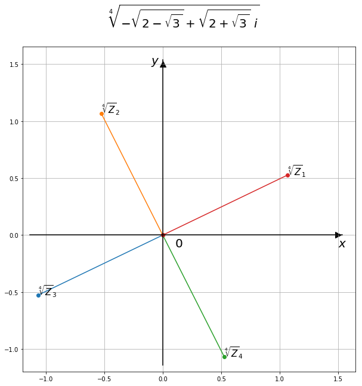

```python
fig, ax = plt.subplots(figsize=(10,10))
ax.grid(True); n = [3,2,4,1]; i = 0
for (x,y) in roots:
    ax.plot([0,x],[0,y],'-o')
    ax.annotate('$\sqrt[4]{Z}_{%i}$ ' %n[i], (x,y), fontsize=15);
    i +=1

plt.suptitle('$\sqrt[4]{-\sqrt{2 - \sqrt{3}} + \sqrt{2 + \sqrt{3}} \ i } $', fontsize=20)
plt.text(1.5,-0.1,r'$x$', fontsize=20)
plt.text(-0.1,1.5,r'$y$', fontsize=20)
plt.text(0.1,-0.1,r'$0$', fontsize=20)

plt.scatter(0,1.5, marker='^', s=100, c='black')
plt.scatter(1.5,0, marker='>', s=100, c='black')
ax.axvline(0,0.02,0.96,c='black'); ax.axhline(0,0.02,0.96,c='black');
```